# Data Envelopment Analysis(DEA)

Shashidhar Reddy Boreddy

2022-10-29

```r
# Uploading The Required Libraries
library(Benchmarking)
library(tidyverse)
#Compute the Formulation
#In this section, we will create a matrix and values
#creating the vectors with our values
input_values <- matrix(c(150, 400, 320, 520, 350, 320,
0.2, 0.7, 1.2, 2.0, 1.2, 0.7), ncol=2)
output_values <- matrix(c(14000, 14000, 42000, 28000, 19000, 14000,
3500, 21000, 10500, 42000, 25000, 15000), ncol=2)
# Defining column names
colnames(input_values) <- c("Staff Hours Per Day", "Supplies Per Day")
colnames(output_values) <- c("Reimbursed Patient-Days", "Privately Paid Patient-Days")
#To view the input_values values
input_values
```

```
##      Staff Hours Per Day Supplies Per Day
## [1,]                 150              0.2
## [2,]                 400              0.7
## [3,]                 320              1.2
## [4,]                 520              2.0
## [5,]                 350              1.2
## [6,]                 320              0.7
```

```r
# To view the output_values values
output_values
```

```
##      Reimbursed Patient-Days Privately Paid Patient-Days
## [1,]                   14000                        3500
## [2,]                   14000                       21000
## [3,]                   42000                       10500
## [4,]                   28000                       42000
## [5,]                   19000                       25000
## [6,]                   14000                       15000
```

```r
#As we can see, we are obtaining the identical numbers as in the performance data table from the six nursing facilities operated by Hope Valley Health Care Association.
#In the next part, we will conduct a Data Envelopment Analysis (DEA), which is an analytical method that may assist businesses in identifying and allocating resources to improve efficiency and practice.
```

```r
#FDH-based DEA Analysis
#Now we'll use FDH to define and compute the DEA analysis.The Free disposability hull (FDH) is the assumption that undesirable inputs and outputs are discarded. "We can always create fewer outputs with more inputs because we have free disposability."
#Giving the input_values and output_values.
Anal.FDH<- dea(input_values,output_values,RTS = "FDH")
#Making a data frame with efficiency values.
EV.FDH <- as.data.frame(Anal.FDH$eff)
#  assigning an appropiate name
colnames(EV.FDH) <- c("Efficiency_FDH")
# Identification of peers
p.FDH <- peers(Anal.FDH)
# assigning an appropiate name for peers
colnames(p.FDH) <- c("Peer1_FDH")
# Using the lambda function, determine the relative weights assigned to peers.
lambda_FDH <- lambda(Anal.FDH)
#  giving Lambda exact column name
colnames(lambda_FDH) <- c("L1_FDH", "L2_FDH", "L3_FDH", "L4_FDH", "L5_FDH", "L6_FDH")
# Creating a tabular data with peer, lambda, and efficiency
peer_lambda_EV.FDH <- cbind(p.FDH, lambda_FDH, EV.FDH)
# displaying  summary chart
peer_lambda_EV.FDH
```

| Peer1_FDH | L1_FDH | L2_FDH | L3_FDH | L4_FDH | L5_FDH | L6_FDH | Efficiency_FDH |
| --- | --- | --- | --- | --- | --- | --- | --- |
| 1 | 1 | 0 | 0 | 0 | 0 | 0 | 1 |
| 2 | 0 | 1 | 0 | 0 | 0 | 0 | 1 |
| 3 | 0 | 0 | 1 | 0 | 0 | 0 | 1 |
| 4 | 0 | 0 | 0 | 1 | 0 | 0 | 1 |
| 5 | 0 | 0 | 0 | 0 | 1 | 0 | 1 |
| 6 | 0 | 0 | 0 | 0 | 0 | 1 | 1 |

# displaying the Plot results

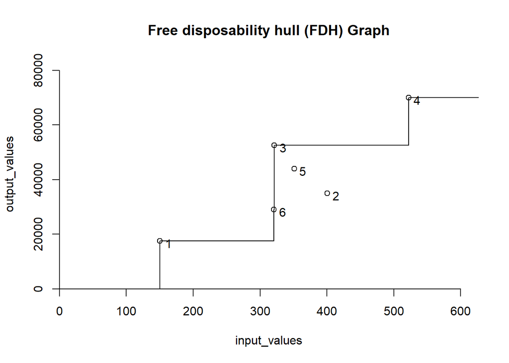

```r
dea.plot(input_values,output_values,RTS="FDH",ORIENTATION="in-out",txt=TRUE, xlab = "input_values", ylab= "output_values", main="Free disposability hull (FDH) Graph")
```

```r
#CRS-based DEA Analysis
#Now we'll formulate and calculate the DEA analysis with Constant Returns to Scale (CRS).The CRS is part of the scaling assumption, and it helps us to evaluate if there are any feasible scaling up or down combinations.
# Giving the input_values and output_values
Anal.CRS <- dea(input_values,output_values,RTS = "CRS")
# observing the effciency values
EV.CRS <- as.data.frame(Anal.CRS$eff)
#  assigning a appropiate name
colnames(EV.CRS) <- c("Efficiency_CRS")
# Identification of peers
Peers_CRS <- peers(Anal.CRS)
# assigning an appropiate name
colnames(Peers_CRS) <- c("Peer1_CRS", "Peer2_CRS", "Peer3_CRS")
# Identifying the relative weights given to the peers using lambda function
lambda_CRS <- lambda(Anal.CRS)
#  assign a appropiate column name for Lambda
colnames(lambda_CRS) <- c("L1_CRS", "L2_CRS", "L3_CRS", "L4_CRS")
# Create a tabular data with peer, lambda, and efficiency
Peers_lambda_EV.CRS <- cbind(Peers_CRS, lambda_CRS, EV.CRS)
#displaying  summary chart
Peers_lambda_EV.CRS
```

| Peer1_CRS | Peer2_CRS | Peer3_CRS | L1_CRS | L2_CRS | L3_CRS | L4_CRS | Efficiency_CRS |
| --- | --- | --- | --- | --- | --- | --- | --- |
| 1 | NA | NA | 1.0000000 | 0.00000000 | 0 | 0.0000000 | 1.0000000 |
| 2 | NA | NA | 0.0000000 | 1.00000000 | 0 | 0.0000000 | 1.0000000 |
| 3 | NA | NA | 0.0000000 | 0.00000000 | 1 | 0.0000000 | 1.0000000 |
| 4 | NA | NA | 0.0000000 | 0.00000000 | 0 | 1.0000000 | 1.0000000 |
| 1 | 2 | 4 | 0.2000000 | 0.08048142 | 0 | 0.5383307 | 0.9774987 |
| 1 | 2 | 4 | 0.3428571 | 0.39499264 | 0 | 0.1310751 | 0.8674521 |

#In terms of Constant Returns to Scale (CRS), the facilities 1, 2, 3, and 4 are utilizing all of their efficiency, as demonstrated by the lambdas and peers. Facility 5 and 6, on the other hand, require portions of 1, 2, and 4, as demonstrated by the peers and lambdas above. It suggests that these two facilities (5 and 6) have opportunity to improve because their efficiency rates are 97.74% and 86.74%, respectively.

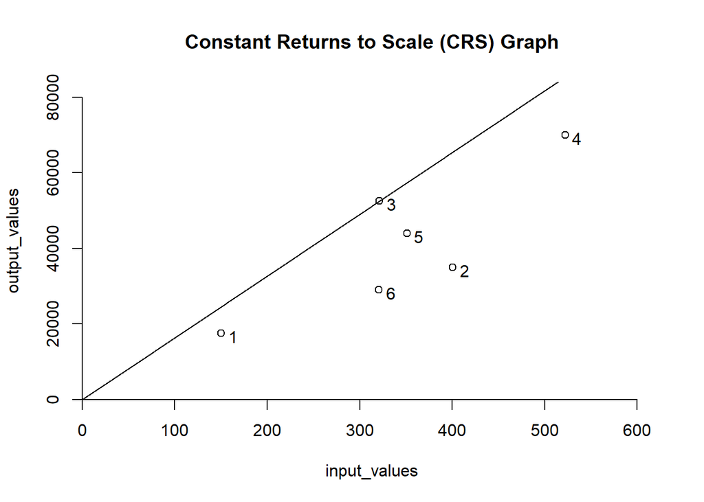

```r
# displaying the Plot  results
dea.plot(input_values,output_values,RTS="crs",ORIENTATION="in-out",
txt=TRUE, xlab = 'input_values', ylab= 'output_values', main="Constant Returns to Scale (CRS) Graph")
```

```r
#VRS DEA Analysis
#Now we will construct and calculate the DEA analysis utilizing Variable Returns to Scale (VRS). VRS is also part of the scaling assumption, and it aids in estimating the efficiency of the variables whether An increase or reduction is not proportionate.
# Giving the input_values and output_values
Anal.VRS <- dea(input_values,output_values,RTS = "VRS")
# To observe effciency values
EV.VRS <- as.data.frame(Anal.VRS$eff)
#  assigning an appropiate name
colnames(EV.VRS) <- c("Efficiency_VRS")
# Identify the peers
Peers_VRS <- peers(Anal.VRS)
# assigning an appropiate name
colnames(Peers_VRS) <- c("Peer1_VRS", "Peer2_VRS", "Peer3_VRS")
# Identify the relative weights given to the peers using lambda function
lambda_VRS <- lambda(Anal.VRS)
# To assign an appropiate column name for Lambda
colnames(lambda_VRS) <- c("L1_VRS", "L2_VRS", "L3_VRS", "L4_VRS", "L5_VRS")
# Create a tabular data with peer, lambda, and efficiency
peers_lambda_EV.VRS <- cbind(Peers_VRS, lambda_VRS, EV.VRS)
#displaying  summary chart
peers_lambda_EV.VRS
```

| Peer1_VRS | Peer2_VRS | Peer3_VRS | L1_VRS | L2_VRS | L3_VRS | L4_VRS | L5_VRS | Efficiency_VRS |
| --- | --- | --- | --- | --- | --- | --- | --- | --- |
| 1 | NA | NA | 1.0000000 | 0.0000000 | 0 | 0 | 0.0000000 | 1.0000000 |
| 2 | NA | NA | 0.0000000 | 1.0000000 | 0 | 0 | 0.0000000 | 1.0000000 |
| 3 | NA | NA | 0.0000000 | 0.0000000 | 1 | 0 | 0.0000000 | 1.0000000 |
| 4 | NA | NA | 0.0000000 | 0.0000000 | 0 | 1 | 0.0000000 | 1.0000000 |
| 5 | NA | NA | 0.0000000 | 0.0000000 | 0 | 0 | 1.0000000 | 1.0000000 |
| 1 | 2 | 5 | 0.4014399 | 0.3422606 | 0 | 0 | 0.2562995 | 0.8963283 |

#When we run the Variable Returns to Scale (VRS), we can see that facilities 1, 2, 3, 4, and 5 are all operating at full capacity or efficiency. This is not the case with facility 6, which has an efficiency of 89.63%. Peers and lambdas indicate that facility 6 requires parts of facilities 1, 2, and 5 to be more efficient.

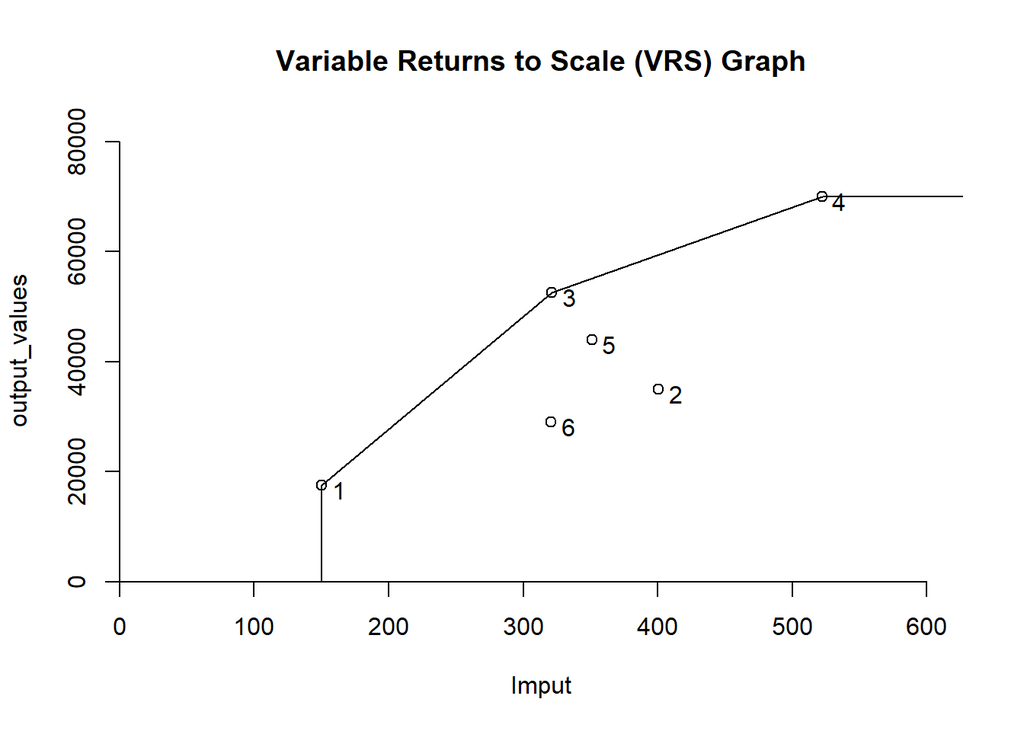

```r
# displaying the Plot  results
dea.plot(input_values,output_values,RTS="vrs",ORIENTATION="in-out",
txt=TRUE, xlab ='Imput', ylab = 'output_values', main ="Variable Returns to Scale (VRS) Graph")
```

```r
#IRS Analysis for DEA
#Now we'll formulate and compute the DEA analysis with Increasing Returns to Scale (IRS).IRS shows whether or not the operation scale may be created.
# Giving the input_values and output_values
Anal.IRS <- dea(input_values,output_values,RTS = "irs")
# observe effciency values
EV.IRS <- as.data.frame(Anal.IRS$eff)
#  assigning an appropiate name
colnames(EV.IRS) <- c("Efficiency_IRS")
# Identify the peers
Peers_IRS <- peers(Anal.IRS)
#  assign an appropiate name
colnames(Peers_IRS) <- c("Peer1_IRS", "Peer2_IRS", "Peer3_IRS")
# Identify the relative weights given to the peers using lambda function
lambda_IRS <- lambda(Anal.IRS)
#  assigning an appropiate column name for Lambda
colnames(lambda_IRS) <- c("L1_IRS", "L2_IRS", "L3_IRS", "L4_IRS", "L5_IRS")
# Create a tabular data with peer, lambda, and efficiency
peers_lambda_EV.IRS <- cbind(Peers_IRS, lambda_IRS, EV.IRS)
#displaying  summary chart
peers_lambda_EV.IRS
```

| Peer1_IRS | Peer2_IRS | Peer3_IRS | L1_IRS | L2_IRS | L3_IRS | L4_IRS | L5_IRS | Efficiency_IRS |
| --- | --- | --- | --- | --- | --- | --- | --- | --- |
| 1 | NA | NA | 1.0000000 | 0.0000000 | 0 | 0 | 0.0000000 | 1.0000000 |
| 2 | NA | NA | 0.0000000 | 1.0000000 | 0 | 0 | 0.0000000 | 1.0000000 |
| 3 | NA | NA | 0.0000000 | 0.0000000 | 1 | 0 | 0.0000000 | 1.0000000 |
| 4 | NA | NA | 0.0000000 | 0.0000000 | 0 | 1 | 0.0000000 | 1.0000000 |
| 5 | NA | NA | 0.0000000 | 0.0000000 | 0 | 0 | 1.0000000 | 1.0000000 |
| 1 | 2 | 5 | 0.4014399 | 0.3422606 | 0 | 0 | 0.2562995 | 0.8963283 |

#Rising Returns to Scale (IRS) is the same as Variable Returns to Scale (VRS) since facilities 1, 2, 3, 4, and 5 are all operating at full capacity, while facility 6 requires improvements from units 1, 2, and 5 to enhance their efficiency, which is 89.63%.

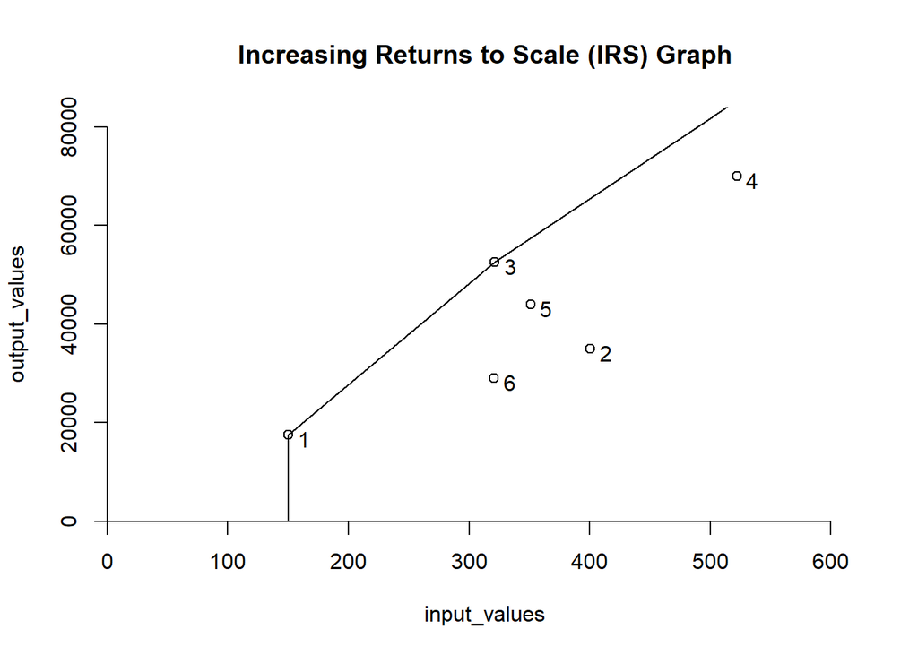

```r
# displaying the Plot  results
dea.plot(input_values,output_values,RTS="irs",ORIENTATION="in-out",
txt=TRUE, xlab = 'input_values', ylab= 'output_values', main="Increasing Returns to Scale (IRS) Graph")
```